# South Korea District Heat Calibration

Author

Haewon McJeon

Published

September 3, 2026

## Summary

This work has two parts: (1) giving South Korea its own energy balance, separate from the global IEA-derived balance every other region shares, and (2) using that separation to calibrate district heat as a proper technology in Korea’s buildings sector, which previously didn’t exist there at all.

Branch: `hcm/proj/heatkorea`.

## Part 1: separating Korea’s energy balance from the global IEA balance

### What changed

| File | Change |
| --- | --- |
| `R/zenergy_K101.en_bal_KOR.R` (new) | Overlays Korea’s rows in the global IEA energy balance with a Korea-specific balance, so Korea’s numbers can diverge from the global-average calculation without touching any other region |
| `energy/KOR_en_bal.csv` (new) | The Korea-specific sector x fuel x year energy balance overlay consumed by K101 |
| `R/zenergy_L1011.en_bal_adj.R` | Downstream input redirected from the global balance to the new Korea-overlaid balance (K101) |

### Why

GCAM’s global IEA energy balance has no district-heat line item for Korea, so historically all of Korea’s district-heat energy was absorbed into other fuel categories. To fix this without perturbing any other region’s calibration, Korea’s rows are overlaid with a Korea-specific balance (`K101`, “Korea, level-1 chunk 01”) rather than editing the shared global balance directly. Every other region’s data is untouched except through legitimate global trade effects (e.g. gas/biomass markets).

`K101` sits between `L101` (the global IEA balance) and `L1011` (an existing downstream adjustment chunk, unrenamed since it isn’t Korea-specific code): `L101 → K101 (Korea overlay) → L1011 → ... → L224 (district heat sector)`.

## Part 2: district heat calibration

South Korea had `has_district_heat = 0` in `A_regions.csv`, so even after Part 1 gave Korea its own energy balance, that district-heat energy was still folded into other fuels downstream, and GCAM never modeled Korean district heat as its own technology. This part turns district heat on for South Korea and calibrates it as a proper technology competing inside `resid heating`, `resid others`, `comm heating`, and `comm others`.

### What changed

| File | Change |
| --- | --- |
| `energy/A_regions.csv` | `has_district_heat` for South Korea: 0 → 1 |
| `energy/share_districtheat_korea.csv` (new) | Placeholder 70:30 heating:others split for how Korea’s district-heat energy divides between the “heating” and “others” building services |
| `R/zenergy_L144.building_det_en.R` | Applies the 70:30 split above to Korea’s building-sector heat energy |
| `R/zenergy_L224.heat.R` | Removes Korea’s district-heat “gas” subsector from the `fixed` share-weight interpolation rule that otherwise permanently freezes it at its last-calibrated (CHP-suppressed) share |
| `input/extra/korea_district_heat_2021_cost_override.xml` (new) | Standalone XML scenario component: sets South Korea district-heat biomass non-energy cost to $1/GJ for 2005-2021 |
| `exe/configuration_ref.xml` | Adds the cost-override XML as a scenario component, right after `heat.xml` |

### Why

**The 70:30 heating/others split.** District heat needs to be divided between the “heating” and “others” (water heating, etc.) building services. Real Korea District Heating Corporation (KDHC) data was not available during this work, so a flat 70:30 placeholder is used for all historical years. This is documented in the CSV header as a placeholder pending real data.

**The gas share-weight fix.** GCAM’s CHP secondary-heat-output convention restricts CHP heat output to calibration years only (a deliberate, long-standing GCAM design choice — CHP-derived heat can otherwise exceed future end-use demand and break model solution for some regions). Because Korea’s historical district-heat gas subsector was calibrated on a CHP-inclusive basis and then had that “fixed” share-weight rule freeze it at its last historical value, gas ended up artificially locked out of future competition against biomass. Removing Korea’s gas subsector from that fixed rule lets it compete normally going forward, using the default fill-out share-weight of 1.

**The 2021 cost override.** Korea’s district-heat cost is a demand-weighted blend across biomass/gas/refined-liquids technologies. Once the CHP convention drops CHP-derived heat after the last calibration year, the blended sector-average cost profile shifts between 2021 and 2025, causing an abrupt ~17.6% price drop and a corresponding artificial jump in modeled total district-heat consumption in 2025. Since 2021 and all earlier years are historical/calibration years — the calibrated quantities do not respond to cost — a single-country, single-technology override of biomass’s 2021 (and, for consistency, 2005/2010/2015) non-energy cost to a round $1/GJ closes that gap without touching any other region or any future-year solved value. It is implemented as a standalone `input/extra` XML scenario component rather than a gcamdata code change, per this repo’s convention for single-variable, single-country overrides.

**WarningThis $1/GJ value is arbitrary — do not remove without replacing the fix**

It is not derived from real Korean cost data. It exists purely to prevent the 2021→2025 consumption jump described above. It is safe to leave as-is because 2005-2021 are all calibration years (fixed quantities, cost has no effect on the calibrated result) — but removing the override will bring the jump back unless it’s replaced with something else that closes the same gap. See the comment in `korea_district_heat_2021_cost_override.xml` for the same note in the actual scenario file. Replace with real KDHC cost data when available.

## Validation

### Total district heat production, by fuel and technology (boiler vs. CHP)

CHP secondary heat output only exists through the last calibration year (2021) by GCAM design; boiler output is solved through 2100. Total production (boiler + CHP combined) is essentially flat across the 2021→2025 transition (0.115 EJ → 0.110 EJ), confirming there is no discontinuity once CHP and boiler are viewed together.

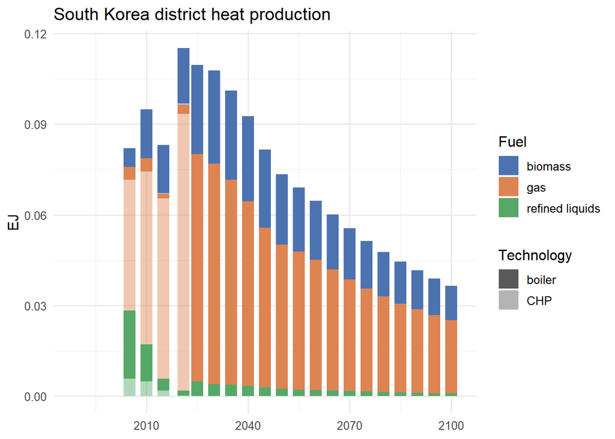

Figure 1: South Korea district heat production by fuel (color) and technology (boiler = solid, CHP = faded)

### District heat consumption in buildings, by sector

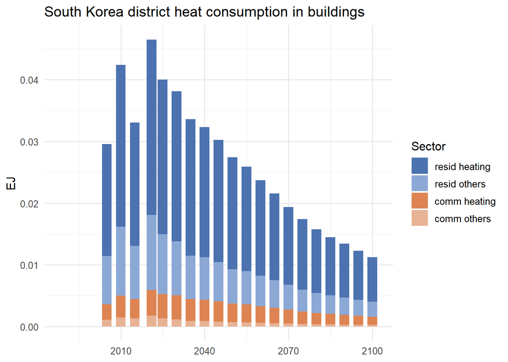

Figure 2: South Korea district heat consumption in buildings, by sector

## Known placeholders / follow-up items

- **70:30 heating/others split** (`share_districtheat_korea.csv`) is a flat assumption for all years, pending real KDHC data.
- **2021 biomass cost override** is arbitrary (see callout above); replace once real historical Korean district-heat costs are available.